# ESPA Simulation and Real Data Application

Pratheepa Jeganathan, Alex Trindade

9/8/2018

```r
library(actuar)#     heavy tailed distributions
```

```r
library(survival)
library(logspline) # Suffices to use logspline, the relevant ones in polspline are identical.
#library(polspline)
require(ggplot2)
require(gridExtra)
```

## loading necessary functions

ESPA PDF

```r
source("./Emp_SPA_pdf_t.R")
```

ESPA support

```r
source("./Emp_SPA_Dist_Supp.R")
```

ESPS survival

```r
source("./Emp_SPA_Survival_t.R")
```

## Simulation

- simulation from failure time ~ Weibull(shape=my.shape,scale=my.scale)
- if model #4 ~ log-logistic(shape=my.shape,scale=my.scale)
- simulation from censoring time ~ exp(rate=1/my.scale)
- % of censoring = target.cen
- make the largest observation censored
- Function Inputs:
  - n,
  - target censoring rate %,
  - parameters of dist,
  - model.num = model # (1-4)
- Returns: df.list, a list with 100 elements, each element of list is a rep, and is a data.frame with two columns (time, status).

```r
Simulate.Right.Censor.Data <- function(n,
                                       target.cen,
                                       my.shape,
                                       my.scale,
                                       model.num){
      set.seed(1000)
      m <- 1
      df.list <- list()
      while(m <= 100){# number of simulation reps
        t <- rweibull(n, shape=my.shape, scale=my.scale)
        if (model.num==4) t = rllogis(n, shape=my.shape)
        c <- rexp(n, rate=1/my.scale)
        #c <- rweibull(n, shape=my.shape, scale=my.scale) # to use the same censroing Y as T
        z <- pmin(t,c)
        time <- z
        status <- ifelse(t<=c,1,0)
        ## simulate <= target censoring rate and the largest obs is censored
        per.cen <- (n-sum(status))/n*100
        if(per.cen > target.cen|per.cen < (target.cen-5)|(status[which(time==max(time))]==1)){next}
        df.list[[m]] <- data.frame(time=time,status=status)
        m=m+1
      }
      return(df.list)
}
```

### Model 1: Weibull(shape=1,scale=10).

- Hazard: h(t)=const.

```r
out=Simulate.Right.Censor.Data(10,30,1,10,1)
saveRDS(out,"./simulated-data/df.list.model1_n10_c30.rds")
out=Simulate.Right.Censor.Data(10,60,1,10,1)
saveRDS(out,"./simulated-data/df.list.model1_n10_c60.rds")

out=Simulate.Right.Censor.Data(25,30,1,10,1)
saveRDS(out,"./simulated-data/df.list.model1_n25_c30.rds")
out=Simulate.Right.Censor.Data(25,60,1,10,1)
saveRDS(out,"./simulated-data/df.list.model1_n25_c60.rds")

out=Simulate.Right.Censor.Data(100,30,1,10,1)
saveRDS(out,"./simulated-data/df.list.model1_n100_c30.rds")
out=Simulate.Right.Censor.Data(100,60,1,10,1)
saveRDS(out,"./simulated-data/df.list.model1_n100_c60.rds")
```

### Model 2: Weibull(shape=1/3,scale=10)

- Hazard: h(t) = monotone decreasing

```r
out=Simulate.Right.Censor.Data(10,30,1/3,10,2)
saveRDS(out,"./simulated-data/df.list.model2_n10_c30.rds")
out=Simulate.Right.Censor.Data(10,60,1/3,10,2)
saveRDS(out,"./simulated-data/df.list.model2_n10_c60.rds")

out=Simulate.Right.Censor.Data(25,30,1/3,10,2)
saveRDS(out,"./simulated-data/df.list.model2_n25_c30.rds")
out=Simulate.Right.Censor.Data(25,60,1/3,10,2)
saveRDS(out,"./simulated-data/df.list.model2_n25_c60.rds")

out=Simulate.Right.Censor.Data(100,30,1/3,10,2)
saveRDS(out,"./simulated-data/df.list.model2_n100_c30.rds")
out=Simulate.Right.Censor.Data(100,60,1/3,10,2)
saveRDS(out,"./simulated-data/df.list.model2_n100_c60.rds")
```

### Model 3: Weibull(shape=2,scale=sqrt(2/3))

- Hazard: h(t) = monotone increasing

```r
out=Simulate.Right.Censor.Data(10,30,2,sqrt(2/3),3)
saveRDS(out,"./simulated-data/df.list.model3_n10_c30.rds")
out=Simulate.Right.Censor.Data(10,60,2,sqrt(2/3),3)
saveRDS(out,"./simulated-data/df.list.model3_n10_c60.rds")

out=Simulate.Right.Censor.Data(25,30,2,sqrt(2/3),3)
saveRDS(out,"./simulated-data/df.list.model3_n25_c30.rds")
out=Simulate.Right.Censor.Data(25,60,2,sqrt(2/3),3)
saveRDS(out,"./simulated-data/df.list.model3_n25_c60.rds")

out=Simulate.Right.Censor.Data(100,30,2,sqrt(2/3),3)
saveRDS(out,"./simulated-data/df.list.model3_n100_c30.rds")
out=Simulate.Right.Censor.Data(100,60,2,sqrt(2/3),3)
saveRDS(out,"./simulated-data/df.list.model3_n100_c60.rds")
```

### Model 4: Log-Logistic(shape=2, rate=1)

- Hazard: h(t) = increasing then decreasing

```r
out=Simulate.Right.Censor.Data(10,30,2,1,4)
saveRDS(out,"./simulated-data/df.list.model4_n10_c30.rds")
out=Simulate.Right.Censor.Data(10,60,2,1,4)
saveRDS(out,"./simulated-data/df.list.model4_n10_c60.rds")

out=Simulate.Right.Censor.Data(25,30,2,1,4)
saveRDS(out,"./simulated-data/df.list.model4_n25_c30.rds")
out=Simulate.Right.Censor.Data(25,60,2,1,4)
saveRDS(out,"./simulated-data/df.list.model4_n25_c60.rds")

out=Simulate.Right.Censor.Data(100,30,2,10,4)
saveRDS(out,"./simulated-data/df.list.model4_n100_c30.rds")
out=Simulate.Right.Censor.Data(100,60,2,10,4)
saveRDS(out,"./simulated-data/df.list.model4_n100_c60.rds")
```

## Survival Function Plots

ESPA & logspline package approximate the survival functions of right-censored data.

We will also plots KM with 95% confidence bands.

- Model 1: Weibull(shape=1,scale=10), h(t)=const.
- Model 2: Weibull(1/3,10), h(t)=monotone dec.
- Model 3: Weibull(2,sqrt{2/3}), h(t)=monotone inc.
- Model 4: Log-Logistic(shape=2,scale=1), h(t)=inc up to t=1 then dec

Data files are in “simulated-data” folder, m=100 reps from each model with (n=10,25) and censoring percentage 30%,60%.

Each .rds data file is a list, each element of list corresponds to a rep, and is a data.frame with two columns (time, status).

Check for example whether the largest observation in each rep is censored.

```r
df.list <- readRDS("./simulated-data/df.list.model1_n10_c30.rds")
xx=df.list[[3]]
which.order=sort(xx$time, index.return = TRUE)$ix
xx$time[which.order]
```

```
##  [1]  1.240970  1.653667  1.760256  2.295759  4.263199  5.165396  6.080579
##  [8] 12.647103 19.339222 19.790558
```

```r
xx$status[which.order]
```

```
##  [1] 1 0 1 1 1 1 1 1 0 0
```

Define function to compute logsplines survival over a grid - INPUTS: - t.data: data.frame (col1=time, col2=status) - t.grid: grid of quantiles where to compute surv - RETURNS: - vector of survival probs over grid (if oldlogspline succeeded…) - 0 (if oldlogspline did NOT succeeded)

```r
logsplines.surv=function(t.data,
                         t.grid){
      n=length(t.data$time)
      censored.obs = t.data$time[t.data$status==0]
      un.censored.obs = t.data$time[t.data$status==1]
      my.penalty=log(length(un.censored.obs))
      fit <- try(oldlogspline(uncensored=un.censored.obs, right=censored.obs,
                        lbound=0, penalty=my.penalty), silent=T)
      if (is.list(fit)){
          out=poldlogspline(t.grid, fit)
          return(1-out)
      }
      else return(0)
}
```

- Function: plot true + logsplines + ESPA survival functions
  - DEPENDS: on “logsplines.surv” function above.
- INPUTS:
  - t.data: data.frame (col1=time, col2=status)
  - a=shape, b=scale (true Weibull params)
  - model.num: Model # (for plot title)
  - target.cen: censoring % (for plot title)

```r
plot.surv.fits <- function(a,
                           b,
                           t.data,
                           model.num,
                           target.cen,
                           print.legend){
      eps=10^(-4); n=length(t.data$time); blue.is.ok=TRUE
      time=t.data$time; status=t.data$status
      # KM fit
      survob=Surv(time=time,event=status,type='right')
      fit=survfit(survob~1,conf.type="plain")

       # ESPA & true survivals
      source('./Emp_SPA_Dist_Supp.R')
      supp=Emp_SPA_Dist_Supp(time,status)
      my.grid=seq(supp[1],supp[2],by=(supp[2]-supp[1])/100)

      source('./Emp_SPA_Survival_t.R')
      spa.surv=rep(0,length(my.grid)); tru.surv=rep(0,length(my.grid))

      for(i in 1:length(my.grid)){
        spa.surv[i] = Emp_SPA_Survival_t(my.grid[i],time,status)
        tru.surv[i] = 1-pweibull(my.grid[i], shape=a, scale=b)
        if (model.num==4) tru.surv[i] = pllogis(my.grid[i], shape=2, lower.tail=F)
      }

      # get logsplines surv
      spl.surv=logsplines.surv(t.data, my.grid)
      # flag when logsplines did NOT succeed
      if (length(spl.surv)==1) blue.is.ok=FALSE
      # refine grid to be above epsilon
      new.idx=seq(1,length(my.grid))[tru.surv>eps];
      my.grid=my.grid[new.idx]; t.upper=max(my.grid)
      spa.surv=spa.surv[new.idx]
      tru.surv=tru.surv[new.idx]
      if (blue.is.ok) spl.surv=spl.surv[new.idx]
      # plot KM and overlay remianing ones
      plot(fit,lty=c(1,3,3),main='',xlab="time",conf.int=T, ylab="",
         yaxs="i",lwd=2,xlim=c(0,t.upper), col=c("grey","grey","grey"))
      points(my.grid,spa.surv,lwd=2,type='l',col='red',lty=2)
      points(my.grid,tru.surv,lwd=2,type='l',col='black',lty=1)
      if (blue.is.ok) points(my.grid,spl.surv,lwd=2,type='l',col='blue',lty=2)
      if (print.legend) legend('topright',legend=c('KM','ESPA','true','Logsplines'),
                               col=c("grey",'red','black','blue'), lty=c(1,2,1,2))
      title(main=bquote(paste('Survival: Model ',.(model.num),', n=',.(n),
                              ', (',.(target.cen),'% censor)')))
}
```

Analyze runs from Model 1

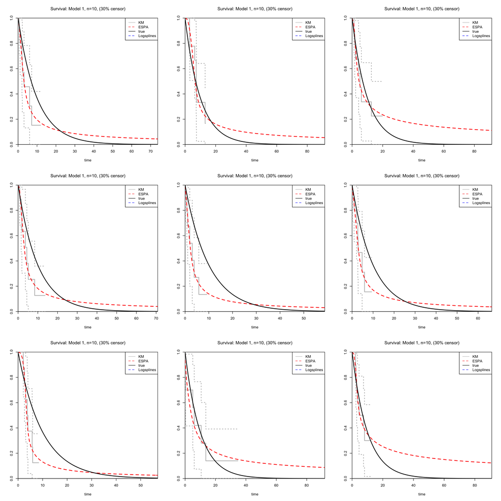

```r
my.shape=1; my.scale=10; my.model=1; my.censor=30
df.list <- readRDS("./simulated-data/df.list.model1_n10_c30.rds")
par(mfrow=c(3,3))
for (i in 1:9){
  plot.surv.fits(my.shape, my.scale, df.list[[i]], my.model, my.censor, TRUE)
}
```

```r
par(mfrow=c(1,1))
#
dev.off()
```

Analyze runs from Model 2

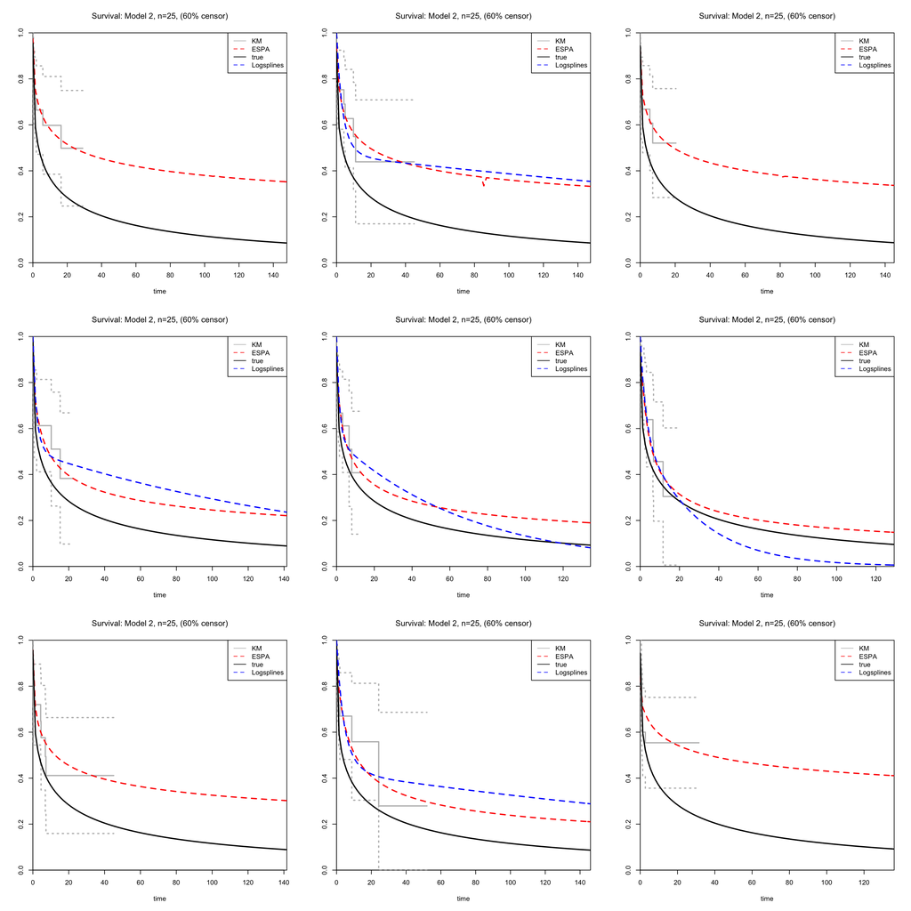

```r
my.shape=1/3; my.scale=10; my.model=2; my.censor=60
df.list <- readRDS("./simulated-data/df.list.model2_n25_c60.rds")
par(mfrow=c(3,3))
for (i in c(1:6,8:10)){
  plot.surv.fits(my.shape, my.scale, df.list[[i]], my.model, my.censor, TRUE)
}
```

```r
par(mfrow=c(1,1))
#
dev.off()
```

Analyze runs from Model 3

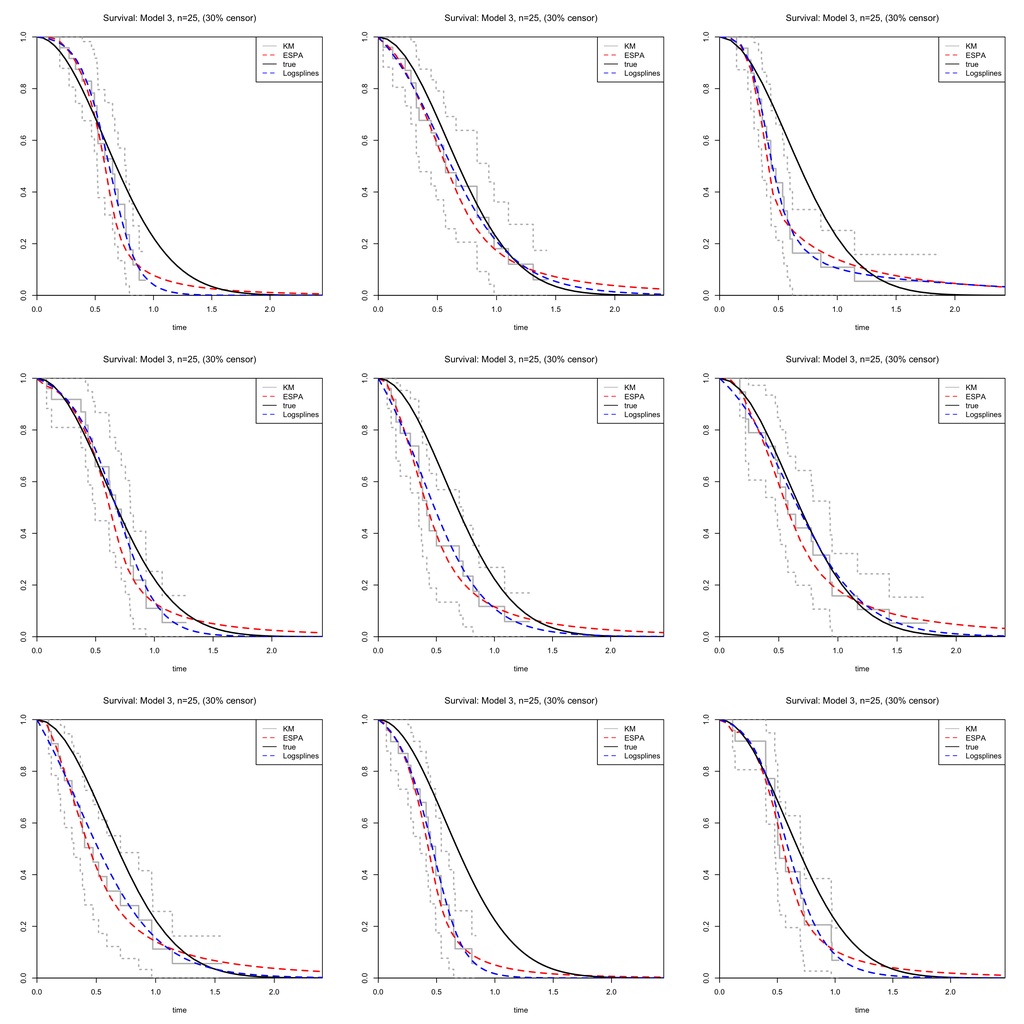

```r
my.shape=2; my.scale=sqrt(2/3); my.model=3; my.censor=30
df.list <- readRDS("./simulated-data/df.list.model3_n25_c30.rds")
par(mfrow=c(3,3))
for (i in 1:9){
  plot.surv.fits(my.shape, my.scale, df.list[[i]], my.model, my.censor, TRUE)
}
```

```r
par(mfrow=c(1,1))
#
dev.off()
```

Analyze runs from Model 4

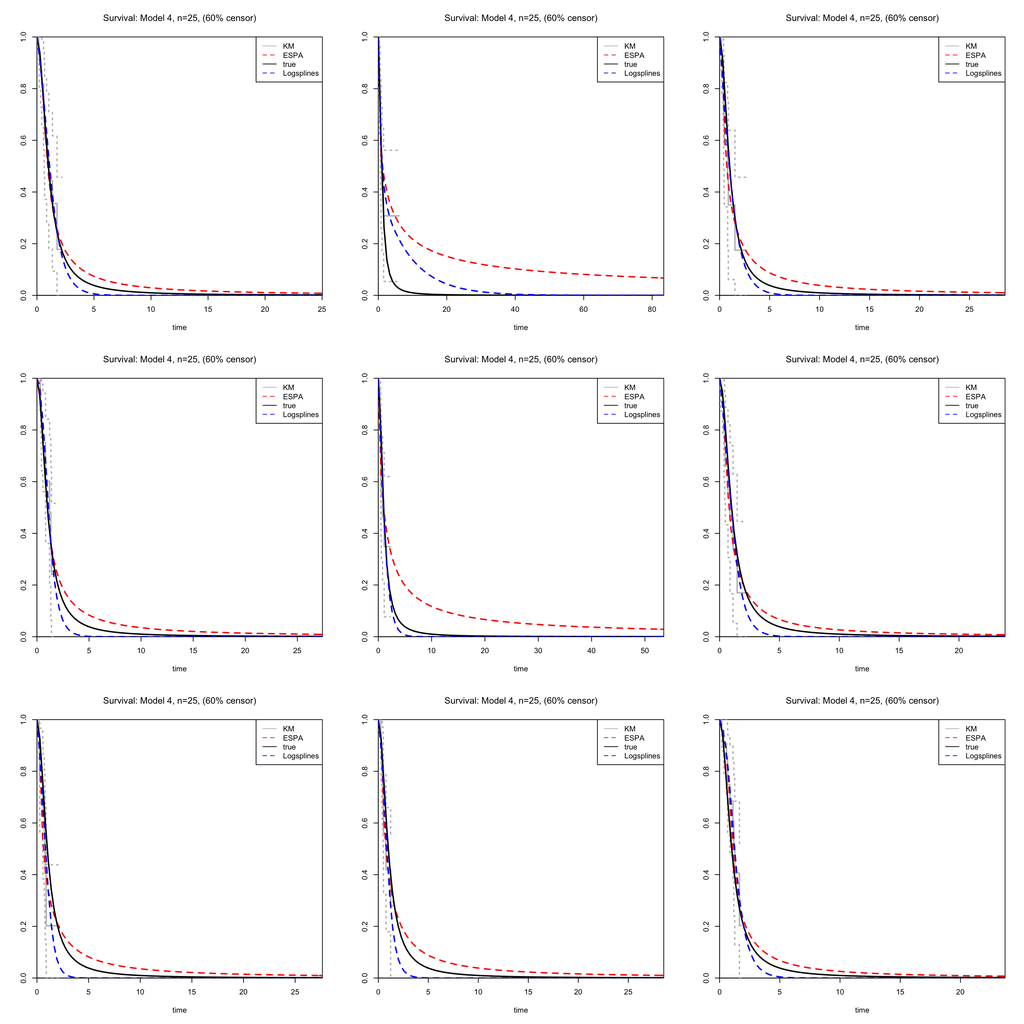

```r
my.shape=2; my.scale=1; my.model=4; my.censor=60
df.list <- readRDS("./simulated-data/df.list.model4_n25_c60.rds")
par(mfrow=c(3,3))
for (i in 1:9){
  plot.surv.fits(my.shape, my.scale, df.list[[i]], my.model, my.censor, TRUE)
}
```

```r
par(mfrow=c(1,1))
#
dev.off()
```

### Survival Plots

#### Analyze runs from Models 1-4 (all in one), n=10, 30% censored

```r
pdf(file="Plots/Model-all-n10-c30.pdf", pointsize=12, paper="a4r",width=0,height=0)
# Mod 1
my.shape=1; my.scale=10; my.model=1; my.censor=30;
df.list <- readRDS("./simulated-data/df.list.model1_n10_c30.rds")
par(mfrow=c(4,4))
for (i in 1:4){
  plot.surv.fits(my.shape, my.scale, df.list[[i]], my.model, my.censor, FALSE)
}
# Mod 2
my.shape=1/3; my.scale=10; my.model=2;
df.list <- readRDS("./simulated-data/df.list.model2_n10_c30.rds")
for (i in 1:4){
  plot.surv.fits(my.shape, my.scale, df.list[[i]], my.model, my.censor, FALSE)
}
# Mod 3
my.shape=2; my.scale=sqrt(2/3); my.model=3;
df.list <- readRDS("./simulated-data/df.list.model3_n10_c30.rds")
for (i in 1:4){
  plot.surv.fits(my.shape, my.scale, df.list[[i]], my.model, my.censor, FALSE)
}
# Mod 4
my.shape=2; my.scale=1; my.model=4;
df.list <- readRDS("./simulated-data/df.list.model4_n10_c30.rds")
for (i in 1:4){
  plot.surv.fits(my.shape, my.scale, df.list[[i]], my.model, my.censor, FALSE)
}
par(mfrow=c(1,1))
#
dev.off()
```

#### Analyze runs from Models 1-4 (all in one), n=25, 30% censored

```r
pdf(file="Plots/Model-all-n25-c30.pdf", pointsize=12, paper="a4r",width=0,height=0)
# Mod 1
my.shape=1; my.scale=10; my.model=1; my.censor=30;
df.list <- readRDS("./simulated-data/df.list.model1_n25_c30.rds")
par(mfrow=c(4,4))
plot.surv.fits(my.shape, my.scale, df.list[[1]], my.model, my.censor, TRUE)
for (i in 2:4){
  plot.surv.fits(my.shape, my.scale, df.list[[i]], my.model, my.censor, FALSE)
}
# Mod 2
my.shape=1/3; my.scale=10; my.model=2;
df.list <- readRDS("./simulated-data/df.list.model2_n25_c30.rds")
for (i in 1:4){
  plot.surv.fits(my.shape, my.scale, df.list[[i]], my.model, my.censor, FALSE)
}
```

```
## * convergence problems, smallest number of knots  tried is  4  *
## * problems are possibly due to a very heavy right tail *
```

```
## * convergence problems, smallest number of knots  tried is  4  *
## * problems are possibly due to a very heavy right tail *
```

```r
# Mod 3
my.shape=2; my.scale=sqrt(2/3); my.model=3;
df.list <- readRDS("./simulated-data/df.list.model3_n25_c30.rds")
for (i in 1:4){
  plot.surv.fits(my.shape, my.scale, df.list[[i]], my.model, my.censor, FALSE)
}
# Mod 4
my.shape=2; my.scale=1; my.model=4;
df.list <- readRDS("./simulated-data/df.list.model4_n25_c30.rds")
for (i in 1:4){
  plot.surv.fits(my.shape, my.scale, df.list[[i]], my.model, my.censor, FALSE)
}
par(mfrow=c(1,1))
#
dev.off()
```

#### Analyze runs from Models 1-4 (all in one), n=10, 60% censored

```r
pdf(file="Plots/Model-all-n10-c60.pdf", pointsize=12, paper="a4r",width=0,height=0)
# Mod 1
my.shape=1; my.scale=10; my.model=1; my.censor=60;
df.list <- readRDS("./simulated-data/df.list.model1_n10_c60.rds")
par(mfrow=c(4,4))
plot.surv.fits(my.shape, my.scale, df.list[[1]], my.model, my.censor, TRUE)
for (i in 2:4){
  plot.surv.fits(my.shape, my.scale, df.list[[i]], my.model, my.censor, FALSE)
}
# Mod 2
my.shape=1/3; my.scale=10; my.model=2;
df.list <- readRDS("./simulated-data/df.list.model2_n10_c60.rds")
for (i in 1:4){
  plot.surv.fits(my.shape, my.scale, df.list[[i]], my.model, my.censor, FALSE)
}
# Mod 3
my.shape=2; my.scale=sqrt(2/3); my.model=3;
df.list <- readRDS("./simulated-data/df.list.model3_n10_c60.rds")
for (i in 1:4){
  plot.surv.fits(my.shape, my.scale, df.list[[i]], my.model, my.censor, FALSE)
}
# Mod 4
my.shape=2; my.scale=1; my.model=4;
df.list <- readRDS("./simulated-data/df.list.model4_n10_c60.rds")
for (i in 1:4){
  plot.surv.fits(my.shape, my.scale, df.list[[i]], my.model, my.censor, FALSE)
}
par(mfrow=c(1,1))
#
dev.off()
```

#### Analyze runs from Models 1-4 (all in one), n=25, 60% censored

```r
pdf(file="Plots/Model-all-n25-c60.pdf", pointsize=12, paper="a4r",width=0,height=0)
# Mod 1
my.shape=1; my.scale=10; my.model=1; my.censor=60;
df.list <- readRDS("./simulated-data/df.list.model1_n25_c60.rds")
par(mfrow=c(4,4))
plot.surv.fits(my.shape, my.scale, df.list[[1]], my.model, my.censor, TRUE)
for (i in 2:4){
  plot.surv.fits(my.shape, my.scale, df.list[[i]], my.model, my.censor, FALSE)
}
# Mod 2
my.shape=1/3; my.scale=10; my.model=2; my.censor=60;
df.list <- readRDS("./simulated-data/df.list.model2_n25_c60.rds")
for (i in 1:4){
  plot.surv.fits(my.shape, my.scale, df.list[[i]], my.model, my.censor, FALSE)
}
# Mod 3
my.shape=2; my.scale=sqrt(2/3); my.model=3; my.censor=60;
df.list <- readRDS("./simulated-data/df.list.model3_n25_c60.rds")
for (i in 1:4){
  plot.surv.fits(my.shape, my.scale, df.list[[i]], my.model, my.censor, FALSE)
}
# Mod 4
my.shape=2; my.scale=1; my.model=4;
df.list <- readRDS("./simulated-data/df.list.model4_n25_c60.rds")
for (i in 1:4){
  plot.surv.fits(my.shape, my.scale, df.list[[i]], my.model, my.censor, FALSE)
}
par(mfrow=c(1,1))
#
dev.off()
```

## Integrated Square Errors of survival approximations

Figures 1, 3, 4, and 5 in the paper

Function to produce ggplot2 plots of ISEs. - It branches depending on whether there are NA’s in the spline ISEs, in which case it only plots the difference (spline-espa). - INPUTS: - b.dat = dataframe returned by Compute.Model.ISEs - my.label = label to print on plot LHS - OUTPUT: out.box & out.den (Boxplot & PDF plot objects)

```r
Get.Box.Pdf.Plots <- function(b.dat, my.label){
  case1=FALSE; case2=FALSE; case3=FALSE;
  idx=which(is.na(b.dat$spline)); m=dim(b.dat)[1]; my.title.size=13
  if (length(idx)==0) case3=TRUE # no NA's -> plot espa & splines separately
  if (length(idx)==m) case1=TRUE # all NA's -> plot only espa
  if (length(idx)>0 && length(idx)<m) case2=TRUE # some NA's -> plot difference
  if (case1){
#    my.label=paste(my.label,": \n 100% of spline method had no solution")
    ise=log(b.dat$espa)
    Method=factor(rep("espa",m))
    df2=data.frame(Method, ise)
    bg2 <- ggplot(df2, aes(Method, ise))
    bg2 <- bg2 + geom_boxplot(aes(fill = Method)) +
       xlab("") + ylab("") + ggtitle(my.label)
    bg2 <- bg2 + scale_fill_manual(values="#E69F00")
    dg2 <- ggplot(df2, aes(x=ise,colour=Method,group=Method))
    dg2 <- dg2 + xlab("log(ISE)") + geom_density(fill="#E69F00")+ylab("")
    dg2 <- dg2 + scale_color_manual(values="#E69F00") + ggtitle(my.label)+
           theme(plot.title = element_text(size=my.title.size, face = "bold"))
  }
  if (case2){
    b.dat=b.dat[-idx,]; m=dim(b.dat)[1]; my.per=100-m
#    my.label=paste(my.label,": \n ",my.per,"% of spline method had no solution")
    ise=log(b.dat$spline)-log(b.dat$espa)
    Method=factor(rep("Difference \n (spline-espa)",m))
    df2=data.frame(Method, ise)
    bg2 <- ggplot(df2, aes(Method, ise))
    bg2 <- bg2 + geom_boxplot(aes(fill = Method)) +
       xlab("") + ylab("") + ggtitle(my.label)
    bg2 <- bg2 + scale_fill_manual(values="#56B4E9")
    dg2 <- ggplot(df2, aes(x=ise, colour=Method, group=Method))
    dg2 <- dg2 + xlab("log(ISE)") + geom_density(fill="#56B4E9")+ylab("")
    dg2 <- dg2 + scale_color_manual(values="#56B4E9")+ ggtitle(my.label)+
           theme(plot.title = element_text(size=my.title.size, face = "bold"))
  }
  if (case3){
    ise=log(c(b.dat$espa,b.dat$spline))
    Method=factor(c(rep("espa",m),rep("spline",m)))
    df2=data.frame(Method, ise)
    bg2 <- ggplot(df2, aes(Method, ise))
    bg2 <- bg2 + geom_boxplot(aes(fill = Method)) +
         xlab("") + ylab("") + ggtitle(my.label)
    dg2 <- ggplot(df2, aes(x=ise, colour=Method, group=Method, linetype=Method))
    dg2 <- dg2 + xlab("log(ISE)") + geom_density(fill=NA)+ ggtitle(my.label)+
           theme(plot.title = element_text(size=my.title.size, face = "bold"))+ylab("")
   }
   out=list("box"=bg2, "den"=dg2)
   return(out)
}
```

- Function: Computes ISEs for logsplines & ESPA survival ftns
- INPUTS:
  - df.list: list of simulated data, each element is data.frame (col1=time, col2=status)
  - my.shape=shape, my.scale=scale (true Weibull params)
  - model.num: model # (1-4)
- RETURNS: data.frame with ISEs in each col (espa, spline, KM)
- The function has sub-functions
  1. true survival function
  2. squared error of ESPA survival
  3. squared error of spline survival approximation
  4. squared error KM

```r
Compute.Model.ISEs <- function(df.list,
                               my.shape,
                               my.scale,
                               model.num){
    source('./Emp_SPA_Dist_Supp.R')
    source('./Emp_SPA_Survival_t.R')

#   true survival function
    t.fun=function(t,shape,scale) 1-pweibull(t,shape=shape,scale=scale)
    if (model.num==4){
        t.fun=function(t,shape,scale) pllogis(t, shape=shape, lower.tail=F)
    }

#   squared error of ESPA survival function
    sq.error.spa=function(x,time,status){
        len.x=length(x); sq.error=numeric(0)
        for(i in 1:len.x){
                true.den=t.fun(x[i],my.shape,my.scale)
                saddle.den=Emp_SPA_Survival_t(x[i],time,status)
                sq.error[i]=(true.den-saddle.den)^2
        }
        return(sq.error)
    }

#   squared error of spline survival function
    sq.error.spl=function(x,time,status){
        true.den=t.fun(x,my.shape,my.scale); len.x=length(x)
        censored.obs = time[status==0]; un.censored.obs = time[status==1]
        my.penalty=log(length(un.censored.obs))
        fit <- try(oldlogspline(uncensored=un.censored.obs, right=censored.obs,
                        lbound=0, penalty=my.penalty), silent=T)
        if (is.list(fit)){
          spline.den=1-poldlogspline(x, fit)
          out=(true.den-spline.den)^2
        } else out=rep(NA,len.x)
        return(out)
    }

#   squared error KM
    sq.error.km=function(x,time,status){
        true.den=t.fun(x,my.shape,my.scale); len.x=length(x)
        survob=Surv(time=time,event=status,type='right')
        fit=survfit(survob~1,conf.type="plain")
        fit.km <- stepfun(fit$time, c(1, fit$surv))
        km.den=fit.km(x)
        out=(true.den-km.den)^2
        return(out)
    }

#   Compute ISEs

    m=length(df.list); ise.spa=rep(0,m); ise.spl=rep(0,m); ise.km=rep(0,m);
        for (i in 1:m){
            t.data = df.list[[i]]
            time = t.data$time; status=t.data$status
            supp = Emp_SPA_Dist_Supp(time,status);
            if(supp[1]==0){
                supp[1] = supp[1]+.01
                }

            ise.spa[i] = tryCatch(integrate(sq.error.spa, supp[1], supp[2], time=time, status=status, abs.tol=.1)$value, error=function(e) NA)

            if (is.na(ise.spa[i])){
              ise.spa[i]=tryCatch(integrate(sq.error.spa, supp[1], supp[2], time=time, status=status, abs.tol=.2)$value, error=function(e) NA)
            }

            ise.spl[i]=tryCatch(integrate(sq.error.spl, supp[1], supp[2], time=time, status=status, abs.tol=.1)$value, error=function(e) NA)

            ise.km[i]=tryCatch(integrate(sq.error.km, supp[1], supp[2], time=time, status=status, abs.tol=.1)$value, error=function(e) NA)
        }

    out=data.frame(espa=ise.spa,spline=ise.spl,km=ise.km)

    return(out)
}
```

### Model 1 survival function log(ISE) values for the ESPA and SPLINE estimators

```r
a=1; b=10
a.list <- readRDS("./simulated-data/df.list.model1_n10_c30.rds")
ise.mod1.n10.c30=Compute.Model.ISEs(a.list, a, b, 1)
a.list <- readRDS("./simulated-data/df.list.model1_n10_c60.rds")
ise.mod1.n10.c60=Compute.Model.ISEs(a.list, a, b, 1)
a.list <- readRDS("./simulated-data/df.list.model1_n25_c30.rds")
ise.mod1.n25.c30=Compute.Model.ISEs(a.list, a, b, 1)
a.list <- readRDS("./simulated-data/df.list.model1_n25_c60.rds")
ise.mod1.n25.c60=Compute.Model.ISEs(a.list, a, b, 1)
a.list <- readRDS("./simulated-data/df.list.model1_n100_c30.rds")
ise.mod1.n100.c30=Compute.Model.ISEs(a.list, a, b, 1)
a.list <- readRDS("./simulated-data/df.list.model1_n100_c60.rds")
ise.mod1.n100.c60=Compute.Model.ISEs(a.list, a, b, 1)
save.image(file="./ISEs/Model1-ISEs.RData")
```

```r
load(file="./ISEs/Model1-ISEs.RData")

out1=Get.Box.Pdf.Plots(ise.mod1.n10.c30,"n=10, c=30% (m=100)")
out2=Get.Box.Pdf.Plots(ise.mod1.n10.c60,"n=10, c=60% (m=100)")
out3=Get.Box.Pdf.Plots(ise.mod1.n25.c30,"n=25, c=30% (m=100)")
out4=Get.Box.Pdf.Plots(ise.mod1.n25.c60,"n=25, c=60% (m=100)")
out5=Get.Box.Pdf.Plots(ise.mod1.n100.c30,"n=100, c=30% (m=100)")
out6=Get.Box.Pdf.Plots(ise.mod1.n100.c60,"n=100, c=60% (m=97)")
## plot all
pdf(file="./Plots/Model1-ISEs-all.pdf", pointsize=12, paper="a4r",width=0,height=0)
grid.arrange(out1$den, out2$den, out3$den, out4$den, out5$den, out6$den, ncol=3, nrow=2)
dev.off()
```

### Model 2 survival function log(ISE) values for the ESPA and SPLINE estimators

```r
a=1/3; b=10
a.list <- readRDS("./simulated-data/df.list.model2_n10_c30.rds")
ise.mod2.n10.c30=Compute.Model.ISEs(a.list, a, b, 2)
a.list <- readRDS("./simulated-data/df.list.model2_n10_c60.rds")
ise.mod2.n10.c60=Compute.Model.ISEs(a.list, a, b, 2)
a.list <- readRDS("./simulated-data/df.list.model2_n25_c30.rds")
ise.mod2.n25.c30=Compute.Model.ISEs(a.list, a, b, 2)
a.list <- readRDS("./simulated-data/df.list.model2_n25_c60.rds")
ise.mod2.n25.c60=Compute.Model.ISEs(a.list, a, b, 2)
a.list <- readRDS("./simulated-data/df.list.model2_n100_c30.rds")
ise.mod2.n100.c30=Compute.Model.ISEs(a.list, a, b, 2)
a.list <- readRDS("./simulated-data/df.list.model2_n100_c60.rds")
ise.mod2.n100.c60=Compute.Model.ISEs(a.list, a, b, 2)
save.image(file="./ISEs/Model2-ISEs.RData")
```

```r
load(file="./ISEs/Model2-ISEs.RData")

out1=Get.Box.Pdf.Plots(ise.mod2.n10.c30,"n=10, c=30% (m=100)")
out2=Get.Box.Pdf.Plots(ise.mod2.n10.c60,"n=10, c=60% (m=100)")
out3=Get.Box.Pdf.Plots(ise.mod2.n25.c30,"n=25, c=30% (m=100)")
out4=Get.Box.Pdf.Plots(ise.mod2.n25.c60,"n=25, c=60% (m=35)")
out5=Get.Box.Pdf.Plots(ise.mod2.n100.c30,"n=100, c=30% (m=83)")
out6=Get.Box.Pdf.Plots(ise.mod2.n100.c60,"n=100, c=60% (m=41)")
## plot all
pdf(file="./Plots/Model2-ISEs-all.pdf", pointsize=12, paper="a4r",width=0,height=0)
grid.arrange(out1$den, out2$den, out3$den, out4$den, out5$den, out6$den, ncol=3, nrow=2)
dev.off()
```

### Model 3 survival function log(ISE) values for the ESPA and SPLINE estimators

```r
a=2; b=sqrt(2/3)
a.list <- readRDS("./simulated-data/df.list.model3_n10_c30.rds")
ise.mod3.n10.c30=Compute.Model.ISEs(a.list, a, b, 3)
a.list <- readRDS("./simulated-data/df.list.model3_n10_c60.rds")
ise.mod3.n10.c60=Compute.Model.ISEs(a.list, a, b, 3)
a.list <- readRDS("./simulated-data/df.list.model3_n25_c30.rds")
ise.mod3.n25.c30=Compute.Model.ISEs(a.list, a, b, 3)
a.list <- readRDS("./simulated-data/df.list.model3_n25_c60.rds")
ise.mod3.n25.c60=Compute.Model.ISEs(a.list, a, b, 3)
a.list <- readRDS("./simulated-data/df.list.model3_n100_c30.rds")
ise.mod3.n100.c30=Compute.Model.ISEs(a.list, a, b, 3)
a.list <- readRDS("./simulated-data/df.list.model3_n100_c60.rds")
ise.mod3.n100.c60=Compute.Model.ISEs(a.list, a, b, 3)
save.image(file="./ISEs/Model3-ISEs.RData")
```

```r
load(file="./ISEs/Model3-ISEs.RData")

out1=Get.Box.Pdf.Plots(ise.mod3.n10.c30,"n=10, c=30% (m=100)")
out2=Get.Box.Pdf.Plots(ise.mod3.n10.c60,"n=10, c=60% (m=100)")
out3=Get.Box.Pdf.Plots(ise.mod3.n25.c30,"n=25, c=30% (m=100)")
out4=Get.Box.Pdf.Plots(ise.mod3.n25.c60,"n=25, c=60% (m=100)")
out5=Get.Box.Pdf.Plots(ise.mod3.n100.c30,"n=100, c=30% (m=100)")
out6=Get.Box.Pdf.Plots(ise.mod3.n100.c60,"n=100, c=60% (m=100)")
## plot all
pdf(file="./Plots/Model3-ISEs-all.pdf", pointsize=12, paper="a4r",width=0,height=0)
grid.arrange(out1$den, out2$den, out3$den, out4$den, out5$den, out6$den, ncol=3, nrow=2)
dev.off()
```

### Model 4 survival function log(ISE) values for the ESPA and SPLINE estimators

```r
a=2; b=1
a.list <- readRDS("./simulated-data/df.list.model4_n10_c30.rds")
ise.mod4.n10.c30=Compute.Model.ISEs(a.list, a, b, 4)
a.list <- readRDS("./simulated-data/df.list.model4_n10_c60.rds")
ise.mod4.n10.c60=Compute.Model.ISEs(a.list, a, b, 4)
a.list <- readRDS("./simulated-data/df.list.model4_n25_c30.rds")
ise.mod4.n25.c30=Compute.Model.ISEs(a.list, a, b, 4)
a.list <- readRDS("./simulated-data/df.list.model4_n25_c60.rds")
ise.mod4.n25.c60=Compute.Model.ISEs(a.list, a, b, 4)
a.list <- readRDS("./simulated-data/df.list.model4_n100_c30.rds")
ise.mod4.n100.c30=Compute.Model.ISEs(a.list, a, b, 4)
a.list <- readRDS("./simulated-data/df.list.model4_n100_c60.rds")
ise.mod4.n100.c60=Compute.Model.ISEs(a.list, a, b, 4)
save.image(file="./ISEs/Model4-ISEs.RData")
```

```r
load(file="./ISEs/Model4-ISEs.RData")
out1=Get.Box.Pdf.Plots(ise.mod4.n10.c30,"n=10, c=30% (m=100)")
out2=Get.Box.Pdf.Plots(ise.mod4.n10.c60,"n=10, c=60% (m=100)")
out3=Get.Box.Pdf.Plots(ise.mod4.n25.c30,"n=25, c=30% (m=100)")
out4=Get.Box.Pdf.Plots(ise.mod4.n25.c60,"n=25, c=60% (m=100)")
out5=Get.Box.Pdf.Plots(ise.mod4.n100.c30,"n=100, c=30% (m=87)")
out6=Get.Box.Pdf.Plots(ise.mod4.n100.c60,"n=100, c=60% (m=94)")
## plot all
pdf(file="./Plots/Model4-ISEs-all.pdf", pointsize=12, paper="a4r",width=0,height=0)
grid.arrange(out1$den, out2$den, out3$den, out4$den, out5$den, out6$den, ncol=3, nrow=2)
dev.off()
```